# miRcore R camp TCGA Group Task

July 21, 2021

# miRcore summer camp 2021

© miRcore

## Disease Information

What is the significance ((background and problems) of the disease you are analyzing?

## Reading in Data

Read in the cancer miRNA expression text file that you downloaded from the Google Drive

```r
lihc_data <- read.table("LIHC.txt",
                        header = 1,
                        row.names = 1,
                        stringsAsFactors = F)
lihc_dataM <- as.matrix(lihc_data)
```

A. What are the dimensions of your text file?

The LIHC data has dimensions of 915, 98.

B. How many Tumor and Control samples are in your dataset?

There are 49 tumor samples and 49 control samples.

## Plotting

B. Make a scatterplot for hsa-miR-200a-3p and hsa-miR-429 using all samples in your data file. Then compute the Pearson correlation.

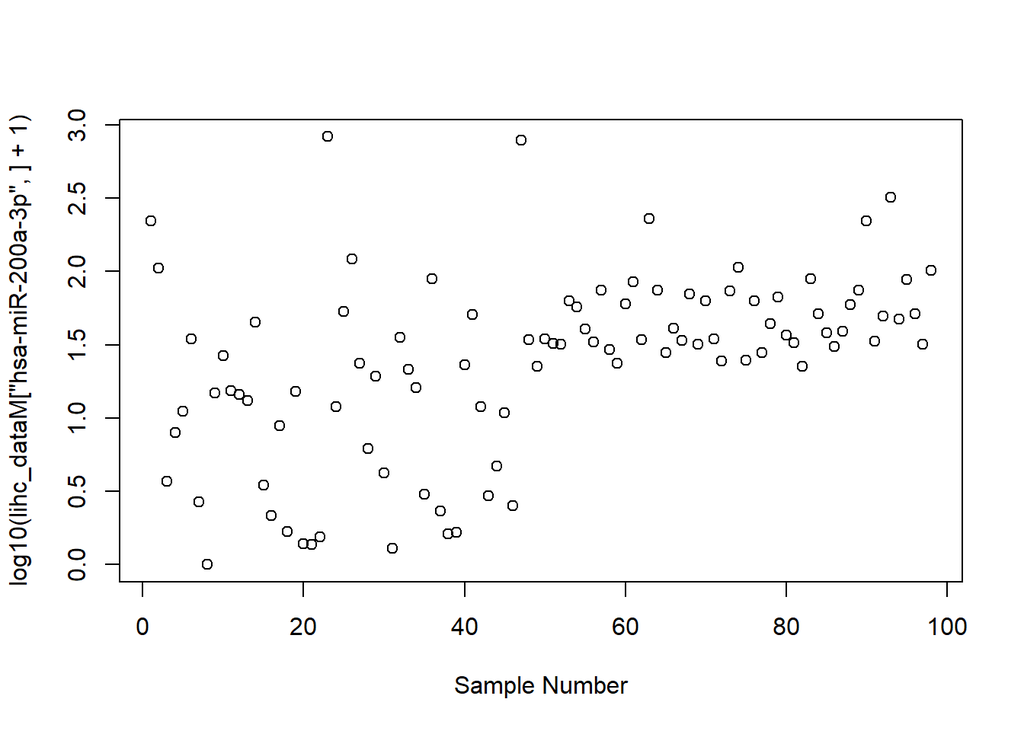

```r
plot(log10(lihc_dataM["hsa-miR-200a-3p",] + 1),
     xlab = "Sample Number")
```

```r
cor(lihc_dataM["hsa-miR-200a-3p", 1:49], lihc_dataM["hsa-miR-200a-3p", 50:98])
```

```
## [1] -0.097401
```

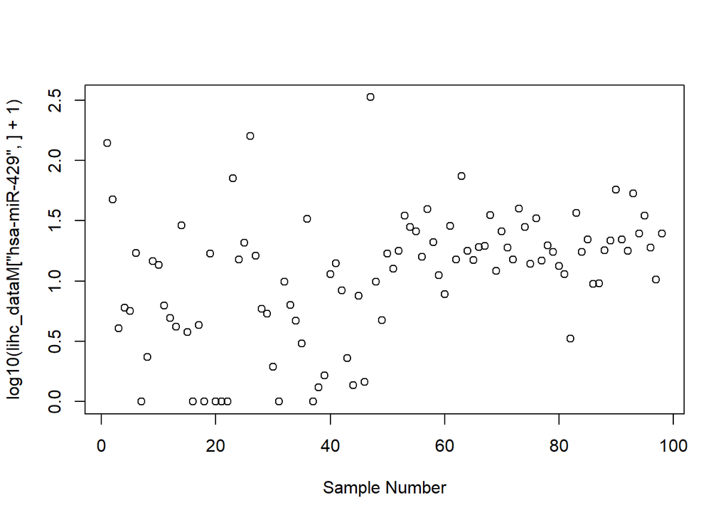

```r
plot(log10(lihc_dataM["hsa-miR-429",] + 1),
     xlab = "Sample Number")
```

```r
cor(lihc_dataM["hsa-miR-429", 1:49], lihc_dataM["hsa-miR-429", 50:98])
```

```
## [1] -0.07191252
```

## T Tests

A. For each miRNA: calculate mean, standard deviation, and the 2-tail student t-test p-value of Tumor and Control groups. Save all results in a table.

```r
name <- vector()
m <- vector()
sd <- vector()
pval <- vector()
ratio <- vector()
for(miRNA in rownames(lihc_dataM)){
  miR_row <- lihc_dataM[miRNA,]
  m <- c(m, mean(miR_row))
  sd <- c(sd, sd(miR_row))
  pval <- c(pval, t.test(miR_row[1:49], miR_row[50:98])$p.val)
  ratio <- c(ratio, mean(miR_row[1:49])/mean(miR_row[50:98]))
}
results <- as.data.frame(cbind(m, sd, pval, ratio))
rownames(results) <- rownames(lihc_dataM)
rmarkdown::paged_table(results)
```

|  | m | sd | pval | ratio |
| --- | --- | --- | --- | --- |
| hsa-let-7a-2-3p | 6.799919e+00 | 5.102153e+00 | 9.307577e-04 | 0.60342308 |
| hsa-let-7b-3p | 2.468290e+01 | 1.379974e+01 | 7.110680e-05 | 0.63964909 |
| hsa-let-7b-5p | 1.110242e+04 | 6.080288e+03 | 3.003002e-02 | 0.78569174 |
| hsa-let-7c-5p | 4.266284e+03 | 2.425305e+03 | 3.166088e-10 | 0.49870953 |
| hsa-let-7d-3p | 3.249361e+02 | 1.420715e+02 | 5.502170e-02 | 1.18640609 |
| hsa-let-7d-5p | 1.843225e+02 | 1.046681e+02 | 1.356820e-01 | 1.18856514 |
| hsa-let-7e-3p | 9.061186e+00 | 5.804948e+00 | 6.779703e-04 | 0.64587544 |
| hsa-let-7e-5p | 8.787718e+02 | 4.805490e+02 | 1.437486e-01 | 1.17649817 |
| hsa-let-7f-1-3p | 2.872479e+00 | 1.409192e+00 | 1.005801e-03 | 0.72440173 |
| hsa-let-7f-2-3p | 1.149985e+00 | 7.456756e-01 | 4.562542e-02 | 0.76899693 |

[output cut: 905 more lines]

2. Find 50 most significantly different miRNA names between tumor and control samples and save their names with means, standard deviations for tumor and control samples and p-values.

```r
sorted_results <- results[order(results$pval),]
sig_miRNA <- lihc_dataM[rownames(sorted_results[1:50,]),]
```

The 50 most significantly different miRNAs are:

```
##  [1] "hsa-miR-139-5p"    "hsa-miR-1258"      "hsa-miR-130a-3p"
##  [4] "hsa-miR-139-3p"    "hsa-miR-24-1-5p"   "hsa-miR-450b-5p"
##  [7] "hsa-miR-122-3p"    "hsa-miR-99a-3p"    "hsa-miR-424-5p"
## [10] "hsa-miR-199b-3p"   "hsa-miR-490-3p"    "hsa-miR-101-5p"
## [13] "hsa-miR-26b-3p"    "hsa-miR-424-3p"    "hsa-miR-542-5p"
## [16] "hsa-miR-378c"      "hsa-let-7c-5p"     "hsa-miR-214-3p"
## [19] "hsa-miR-627-5p"    "hsa-miR-542-3p"    "hsa-miR-30e-5p"
## [22] "hsa-miR-130a-5p"   "hsa-miR-10a-5p"    "hsa-miR-21-5p"
## [25] "hsa-miR-142-3p"    "hsa-miR-10b-3p"    "hsa-miR-144-3p"
## [28] "hsa-miR-214-5p"    "hsa-let-7g-3p"     "hsa-miR-369-5p"
## [31] "hsa-miR-30c-2-3p"  "hsa-miR-145-5p"    "hsa-miR-151a-3p"
## [34] "hsa-miR-99a-5p"    "hsa-miR-142-5p"    "hsa-miR-3614-3p"
## [37] "hsa-miR-589-5p"    "hsa-miR-29c-5p"    "hsa-miR-188-5p"
## [40] "hsa-miR-136-5p"    "hsa-miR-10b-5p"    "hsa-miR-26b-5p"
## [43] "hsa-miR-125b-2-3p" "hsa-miR-1180-3p"   "hsa-miR-30e-3p"
## [46] "hsa-miR-221-3p"    "hsa-miR-3677-3p"   "hsa-miR-27b-3p"
## [49] "hsa-miR-1248"      "hsa-miR-411-5p"
```

C. Make a heatmap of 50 most signficantly differently expressed miRNAs (row clustering only). Use the colors blue, white and red. [USA!USA!USA!].

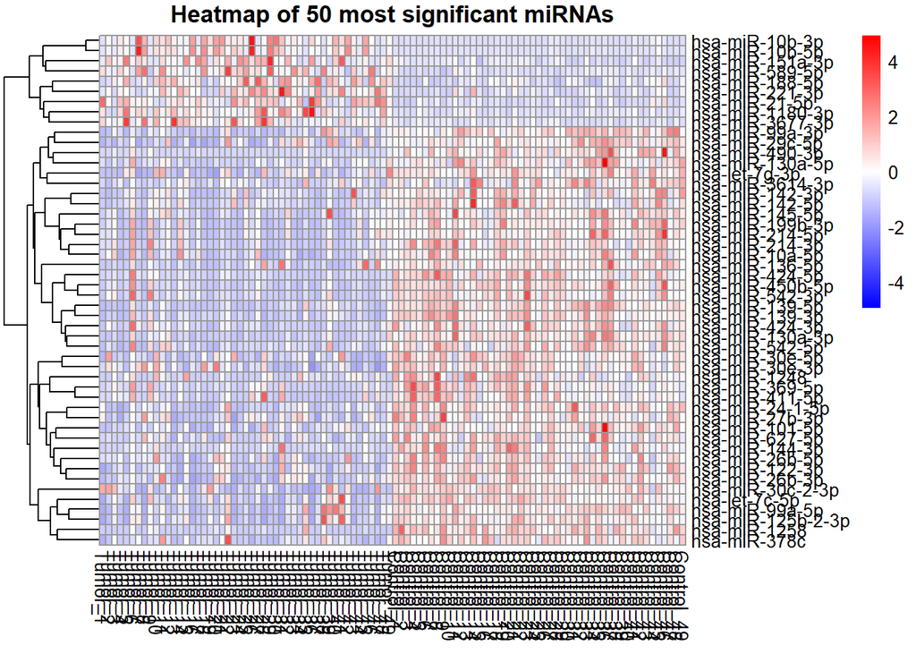

```r
library(pheatmap)
pheatmap(sig_miRNA,
         scale        = "row",
         cluster_cols = F,
         main         = "Heatmap of 50 most significant miRNAs",
         color        = colorRampPalette(c("blue", "white", "red"))(256))
```

## Correlations

A. Find correlations between the most significant miRNA with 29 other miRNAs for 1) all samples.

```r
correlations <- data.frame()
corre <- vector()
miR <- vector()
most_sig <- sig_miRNA[1,]
for(i in 2:30){
  corre <- c(corre, cor(most_sig, sig_miRNA[i,]))
  rownames(sig_miRNA[i,])
  miR <- c(miR, rownames(sig_miRNA)[i])
}
correlations <- cbind.data.frame(corre, miR)
rownames(correlations) <- 1:nrow(correlations)
rmarkdown::paged_table(correlations)
```

|  | corre | miR |
| --- | --- | --- |
| 1 | 0.7034904 | hsa-miR-1258 |
| 2 | 0.8373136 | hsa-miR-130a-3p |
| 3 | 0.8903033 | hsa-miR-139-3p |
| 4 | 0.6569358 | hsa-miR-24-1-5p |
| 5 | 0.7161877 | hsa-miR-450b-5p |
| 6 | 0.6586408 | hsa-miR-122-3p |
| 7 | 0.7080824 | hsa-miR-99a-3p |
| 8 | 0.5974471 | hsa-miR-424-5p |
| 9 | 0.5765826 | hsa-miR-199b-3p |
| 10 | 0.7120360 | hsa-miR-490-3p |

[output cut: 19 more lines]

B. Among A. can you find some patterns between miRNAs? What are your findings? (example: to find the most correlated miRNA with the most significant miRNA)

The most correlated miRNA with the most significant miRNA is **hsa-miR-139-3p** with a correlation of 0.8903033.

The least correlated miRNA with the most significant miRNA is **hsa-miR-21-5p** with a correlation of -0.5980656.

## Random Forest (Bonus)

A. Create a random forest using the steps from the random forest .html file to classify your data. What is your accuracy?

B. Change variables in the random forest run and check if the results are different. What are the parameters that you can achieve a better accuracy?

## Analysis

### miRNAs

What are your most significant miRNAs? Are they up-regulated or down-regulated? Are they highly correlated with each other?

### Genes

A. What are the common gene targets of your significant miRNAs?

B. Are any of your genes targeted by these top miRNAs known mutations of the disease you are researching?

## Conclusion

What do your findings suggest to you about potential diagnosis/treatment targets for the disease you are researching?

## Optional

A. Make a heatmap of all data (row clustering only). Use the colors blue, white and red. [USA!USA!USA!].

B. find all correlations among the 30 most significant miRNAs for 1) all samples, 2) all tumor samples, 3) all control samples.